# Production, Costs, and Firm Supply

Lecture 3

Div Bhagia

# Production Functions

## The Firm’s Production Function

A firm turns inputs into outputs. The **production function** summarizes this:

$$Q = f(K, L)$$

- $Q$: output per period
- $K$: capital (machine-hours)
- $L$: labor (labor-hours)

Shows the *maximum* output from each input combination (efficient production).

## Marginal Productivity

The **marginal product** of an input is the additional output from one more unit of that input, holding other inputs constant:

$$MP_L = \frac{\partial f}{\partial L} = f_L, \qquad MP_K = \frac{\partial f}{\partial K} = f_K$$

**Diminishing marginal productivity:** We assume that marginal products eventually decrease

$$\frac{\partial^2 f}{\partial L^2} = f_{LL} < 0, \qquad \frac{\partial^2 f}{\partial K^2} = f_{KK} < 0$$

Holding capital fixed, each additional worker adds less and less output.

## Average vs. Marginal Productivity

**Average product of labor:**
$$AP_L = \frac{Q}{L} = \frac{f(K,L)}{L}$$

- What people usually mean by “labor productivity”
- Depends on how much capital workers have

**Important:** $AP_L$ depends on $K$ too. When we say “U.S. workers are more productive than Indian workers,” much of that reflects more capital per worker, not inherently more productive labor.

**Cross-productivity effects:** Typically $f_{KL} > 0$ — more capital makes labor more productive and vice versa.

## Isoquants and the RTS

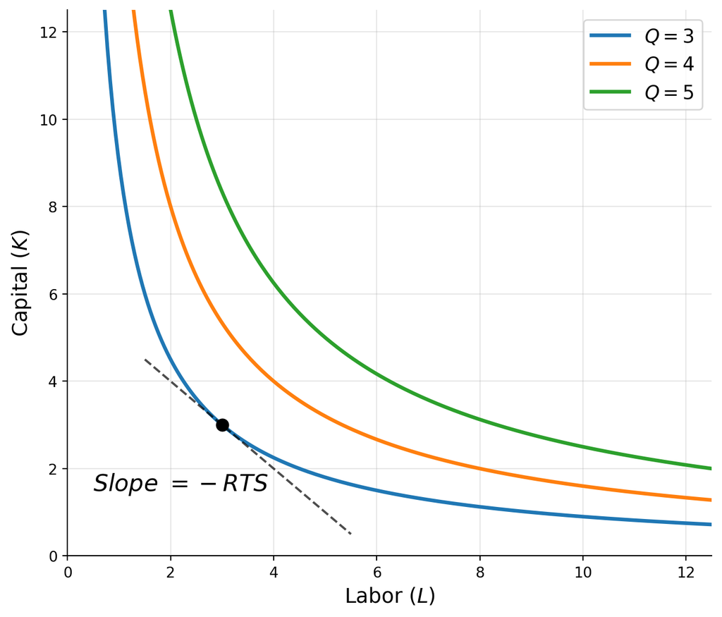

## Analogy to Consumer Theory

| Consumer | Producer |
| --- | --- |
| Utility $U(x,y)$ | Output $f(K,L)$ |
| Budget constraint | Cost constraint |
| Indifference curves | Isoquants |
| MRS | RTS |

## Marginal Rate of Technical Substitution

The **RTS** (rate of technical substitution) is the rate at which labor can substitute for capital, holding output constant:

$$RTS = -\frac{dK}{dL}\bigg|_{Q = \bar{Q}} = \frac{MP_L}{MP_K} = \frac{f_L}{f_K}$$

**Derivation:** Total differential along an isoquant ($dQ = 0$):
$$dQ = f_L \, dL + f_K \, dK = 0 \implies \frac{dK}{dL} = -\frac{f_L}{f_K}$$

**Diminishing RTS:** As we move along an isoquant (more $L$, less $K$), the RTS falls. This means isoquants are **convex** — same logic as diminishing MRS for consumers.

## Elasticity of Substitution

Along an isoquant, RTS decreases as capital-labor ($K/L$) ratio decreases

The **elasticity of substitution** $\sigma$ measures responsiveness of RTS to changes in $K/L$:

$$\sigma = \frac{\%\Delta(K/L)}{\%\Delta RTS} = \frac{d\ln(K/L)}{d\ln(RTS)}$$

$\sigma$ captures how easily the firm can substitute between inputs.

- Higher $\sigma$: inputs are easily substitutable (flatter isoquants)
- Lower $\sigma$: inputs are harder to substitute (more curved isoquants)

## Key Production Functions

| Function | Formula | $\sigma$ |
| --- | --- | --- |
| Linear | $Q = \alpha K + \beta L$ | $\infty$ |
| Leontief | $Q = \min(\alpha K, \beta L)$ | $0$ |
| Cobb-Douglas | $Q = K^\alpha L^\beta$ | $1$ |
| CES | $Q = (\alpha K^\rho + \beta L^\rho)^{\gamma/\rho}$ | $\frac{1}{1-\rho}$ |

CES is appropriate for most applications because it nests the other three as special cases.

## CES Function: Alternative Formulation

The CES function can also be written as:

$$Q = \left[\alpha K^{\frac{\sigma - 1}{\sigma}} + \beta L^{\frac{\sigma - 1}{\sigma}}\right]^{\frac{\sigma}{\sigma - 1}}$$

where $\sigma$ is the elasticity of substitution.

**Applications**:

- Robots vs. human labor: $\sigma$ estimates how easily firms can replace workers with automation
- Energy inputs: $\sigma$ estimates substitutability between fossil fuels and renewables
- International trade: $\sigma$ estimates substitutability between domestic and foreign goods in production

## Returns to Scale

How does output respond when *all* inputs scale proportionally?

| Condition | Returns to Scale |
| --- | --- |
| $f(tK, tL) = t \cdot f(K,L)$ | Constant (CRS) |
| $f(tK, tL) < t \cdot f(K,L)$ | Decreasing (DRS) |
| $f(tK, tL) > t \cdot f(K,L)$ | Increasing (IRS) |

**CRS** implies:

- Production function is homogeneous of degree 1
- Marginal products depend only on the *ratio* $K/L$, not on scale

**Why this matters:** Returns to scale determine the shape of long-run cost curves and industry structure.

# Cost Functions

## Economic vs. Accounting Costs

Economists and accountants think about costs differently:

**Accounting costs:** Out-of-pocket expenses, historical prices, depreciation

**Economic costs:** Opportunity costs i.e. the payment required to keep an input in its present use

**Key differences:**

- **Labor:** Both agree it is wages $w$ per labor-hour.
- **Capital:** Accountant uses historical price + depreciation. Economist uses *rental rate* $r$.
- **Entrepreneurial services:** Accountant counts as profit. Economist recognizes the opportunity cost of the owner’s time and funds.

Total economic cost: $\quad C = rK + wL$

## The Cost-Minimization Problem

$$\min_{K,L} \; rK + wL \quad \text{s.t.} \quad f(K,L) = q_0$$

**Lagrangian:**
$$\mathcal{L} = rK + wL + \lambda[q_0 - f(K,L)]$$

**First-order conditions:**
$$r = \lambda f_K, \qquad w = \lambda f_L, \qquad f(K,L) = q_0$$

Dividing the first two:
$$\frac{f_L}{f_K} = \frac{w}{r} \qquad \Longrightarrow \qquad RTS = \frac{w}{r}$$

## Cost Minimization: Graphically

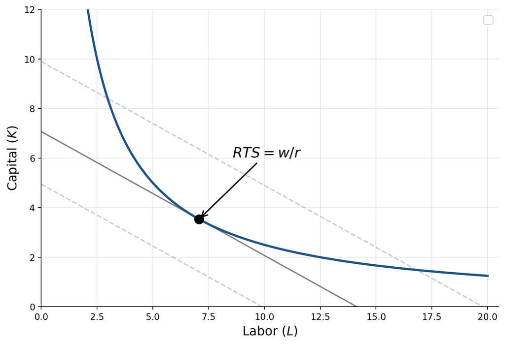

The optimal point is where the isoquant is tangent to the lowest isocost line.

## Interpreting the Lagrange Multiplier

From the first-order conditions:

$$\frac{f_L}{w} = \frac{f_K}{r} = \frac{1}{\lambda}$$

**Interpretation of $\lambda$:**

- Marginal cost of output: $\lambda = \frac{\partial C}{\partial q_0}$
- The extra cost of producing one more unit
- Equal marginal productivity per dollar across all inputs

## Cost Function

The cost function $C(r, w, Q)$ gives the minimum cost of producing $Q$ units given input prices:

$$C(r, w, Q) = rK^*(r,w,Q) + wL^*(r,w,Q)$$

where $K^*$ and $L^*$ are the cost-minimizing input choices from the previous problem.

## Average and Marginal Cost

**Average cost:** $\quad AC = \frac{C(Q)}{Q}$

**Marginal cost:** $\quad MC = \frac{\partial C}{\partial Q}$

**Key relationships:**

- When $MC < AC$: average cost is falling
- When $MC > AC$: average cost is rising
- When $MC = AC$: average cost is at its minimum

**Intuition:** Same as batting average, if your latest at-bat (marginal) is above your average, it pulls the average up.

## Example: Cost Function for Cobb-Douglas

For Cobb-Douglas $Q = K^{0.5} L^{0.5}$, the cost-minimizing inputs are:

$$L^* = \frac{Q}{\sqrt{w/r}}, \qquad K^* = Q \sqrt{w/r}$$

Plugging into the cost function:
$$C(r, w, Q) = wL^* + rK^* = w \cdot \frac{Q}{\sqrt{w/r}} + r \cdot Q \sqrt{w/r} = 2Q\sqrt{rw}$$

Average and marginal cost:

$$AC = \frac{C}{Q} = 2\sqrt{rw}, \qquad MC = \frac{\partial C}{\partial Q} = 2\sqrt{rw}$$

$AC=MC$ and both are constant in $Q$ always for CRS.

## Short-Run vs. Long-Run Costs

**Long run:** All inputs are variable. The firm chooses the cost-minimizing $(K, L)$.

**Short run:** Capital is fixed at $\bar{K}$. The firm can only adjust labor.

$$SC(\bar{K}, w, Q) = r\bar{K} + wL(Q, \bar{K})$$

- **Fixed costs ($r\bar{K}$):** incurred regardless of output
- **Variable costs ($wL$):** vary with output level

**Key result:** Short-run costs $\geq$ long-run costs, with equality only at the output level for which $\bar{K}$ is optimal.

$$SC(Q) \geq C(Q), \qquad SC(q) = C(q) \text{ where } \bar{K} = K^*(q)$$

## Cobb-Douglas: Short-Run Costs

$$\min_L r\bar{K} + wL \quad \text{s.t.} \quad Q = \bar{K}^{0.5} L^{0.5}$$

In the short-run: $L^* = Q^2/\bar{K}$, so the short-run cost function is:
$$SC(\bar{K}, w, Q) = r\bar{K} + w \cdot \frac{Q^2}{\bar{K}}$$

Short-run average, marginal, and average variable cost:

$$SAC = \frac{SC}{Q} = \frac{r\bar{K}}{Q} + w \cdot \frac{Q}{\bar{K}}, \quad SMC = \frac{\partial SC}{\partial Q} = 2w \cdot \frac{Q}{\bar{K}}, \quad SAVC = w \cdot \frac{Q}{\bar{K}}$$

SAC is U-shaped because of the fixed cost component.

# Profit Maximization and Supply

## Profit Maximization

The firm chooses output $Q$ to maximize **economic profit**:

$$\pi = R(Q) - C(Q) = pQ - C(Q)$$

where $R(Q)$ is total revenue and $C(Q)$ is total (economic) cost.

**First-order condition:**
$$\frac{d\pi}{dQ} = \frac{dR}{dQ} - \frac{dC}{dQ} = 0 \implies MR = MC$$

**Second-order condition:**
$$\frac{d^2\pi}{dQ^2} < 0 \implies \frac{dMR}{dQ} < \frac{dMC}{dQ}$$

At the optimum, $MC$ must be rising faster than $MR$.

## Marginal Revenue

**Marginal revenue** is the extra revenue from selling one more unit:

$$MR = \frac{dR}{dQ} = \frac{d(p(Q)\cdot Q)}{dQ} = p + Q\cdot\frac{dp}{dQ}$$

In terms of demand elasticity $e_{Q,p} = \frac{dQ}{dp} \cdot \frac{p}{Q}$, we can rewrite MR as:

$$MR = p\left(1 - \frac{1}{|e_{Q,p}|}\right)$$

For a **price-taking firm**, demand is infinitely elastic

$$|e_{Q,p}| \to \infty \implies MR \to p$$

## Short-Run Supply: Price-Taking Firm

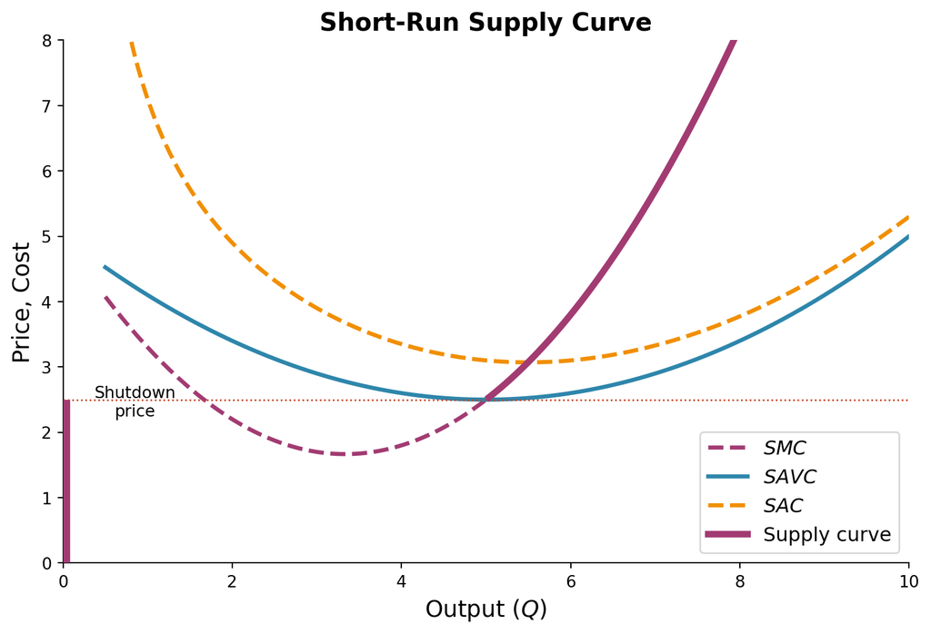

## The Supply Decision

For a **price-taking firm** ($MR = P$), the profit-maximizing rule $MR = MC$ becomes
$$P = MC$$

**Short-run supply curve:** The upward-sloping portion of $SMC$ above minimum $SAVC$.

## The Supply Decision (cont.)

- If $P < \min(SAVC)$: produce nothing (shut down)
  - Revenue doesn’t even cover variable costs
  - Losses are minimized by not producing (lose only fixed costs)
- If $\min(SAVC) \leq P < \min(SAC)$: produce, but at a loss
  - Revenue covers variable costs and some fixed costs
  - Better than shutting down
- If $P \geq \min(SAC)$: produce at a profit

## Producer Surplus

**Producer surplus** measures the benefit to the firm from producing at the market price versus not producing at all.

$$PS = \int_{P_s}^{P} Q(P') \, dP'$$

Producer surplus is the area below the market price and above the supply curve. It’s the surplus that producers earn above their minimum willingness to supply.

# Input Demand

## Profit Maximization and Input Demand

We can also think of the firm as choosing inputs directly:

$$\max_{K,L} \; pf(K,L) - rK - wL$$

**First-order conditions:**

$$p \cdot MP_L = w \qquad \text{and} \qquad p \cdot MP_K = r$$

Hire each input until its **marginal revenue product** equals its price.

- $MRP_L = p \cdot MP_L$: extra revenue from one more unit of labor
- If $MRP_L > w$: hire more labor (adds more revenue than cost)
- If $MRP_L < w$: hire less labor

## Substitution and Output Effects

What happens to labor demand when the wage $w$ falls?

**Two effects (parallel to consumer theory):**

**1. Substitution effect** (holding output constant)

- Lower $w$ makes labor relatively cheaper
- Firm substitutes toward labor, away from capital
- Always increases labor demand

**2. Output effect** (adjusting output)

- Lower $w$ reduces marginal cost
- Firm produces more output
- More output requires more of both inputs (typically)
- Also increases labor demand

## Cross-Price Effects

What about the effect of a wage decrease on *capital* demand?

$$\frac{\partial K}{\partial w} = \; ?$$

**Substitution effect:** $w$ falls → substitute *toward* labor, *away from* capital → less $K$

**Output effect:** $w$ falls → lower costs → more output → more $K$ needed

These work in *opposite* directions. The net effect is ambiguous.